# iDEP: Investigating Differentially Expressed Genes

## If this site has contributed to your work, please cite our article:

Ge, S.X., Son, E.W. & Yao, R. iDEP: an integrated web application for differential expression and pathway analysis of RNA-Seq data. BMC Bioinformatics 19, 534 (2018). https://doi.org/10.1186/s12859-018-2486-6

## Summary

Read Counts data were analyzed using iDEP v2.4.3. The data was first filtered to remove reads below 0.5 CPM in at least 1 sample. Then the data was transformed with EdgeR using a pseudocount of 4. Missing values were imputed using geneMedian.

After mapping, there are 42278 unique genes in 39 samples. Of the 31252 genes passed filter, 31189 were converted to Ensembl/STRING gene IDs in our database. The remaining 63 genes were kept in the data using original IDs.

Differential expression analysis was performed using DESeq2 with an FDR cutoff of 0.1 and a minimum fold-change threshold of 2. Standard Wald test was used and independent filtering was disabled.

## Selected Comparison: DRS-RL

Up-regulated genes: 63

Down-regulated genes: 239

## Top Up-regulated Genes

```r
if (!is.null(params$up_genes_table) && nrow(params$up_genes_table) > 0) {
  kbl(params$up_genes_table, escape = FALSE) %>%
    kable_classic(full_width = FALSE, html_font = "Cambria")
} else {
  print("No up-regulated genes found for this comparison.")
}
```

| Symbol | Ensembl ID | log2 FC | Adj. P-value | Description |
| --- | --- | --- | --- | --- |
| BRA041148 | BRA041148 | 3.725 | 4.40e-36 |  |
| BRA033578 | BRA033578 | 2.985 | 3.98e-06 | AT4G38830 (E=4e-300) \| protein kinase family protein |
| LSU_rRNA_eukarya ENSRNA049460011 | ENSRNA049460011 | 2.723 | 1.21e-07 | Eukaryotic large subunit ribosomal RNA |
| BRA005391 | BRA005391 | 2.723 | 4.11e-03 | AT4G03740 (E=2e-011) \| unknown protein |
| BRA025038 | BRA025038 | 2.565 | 1.02e-02 | AT5G46100 (E=2e-215) \| pentatricopeptide (PPR) repeat-containing protein |
| BRA015668 | BRA015668 | 2.240 | 3.36e-02 | AT1G77490 (E=2e-182) TAPX \| TAPX (THYLAKOIDAL ASCORBATE PEROXIDASE) |
| BRA008676 | BRA008676 | 2.227 | 2.78e-03 | AT5G15780 (E=2e-080) \| pollen Ole e 1 allergen and extensin family protein |
| BRA018956 | BRA018956 | 2.189 | 2.78e-03 | AT1G52240 (E=2e-248) ATROPGEF11, ROPGEF11 \| ROPGEF11 (RHO GUANYL-NUCLEOTIDE EXCHANGE FACTOR 11) |
| BRA037914 | BRA037914 | 2.184 | 5.71e-04 | AT4G10350 (E=4e-193) ANAC070 \| ANAC070 (Arabidopsis NAC domain containing protein 70) |
| BRA000709 | BRA000709 | 1.970 | 5.33e-03 | AT4G10350 (E=4e-197) ANAC070 \| ANAC070 (Arabidopsis NAC domain containing protein 70) |
| BRA034929 | BRA034929 | 1.938 | 1.09e-02 | AT1G42550 (E=0.0) PMI1 \| PMI1 (PLASTID MOVEMENT IMPAIRED1) |
| BRA001950 | BRA001950 | 1.871 | 1.52e-03 | AT3G24480 (E=2e-198) \| leucine-rich repeat family protein / extensin family protein |
| BRA017655 | BRA017655 | 1.819 | 3.26e-03 |  |
| BRA001415 | BRA001415 | 1.779 | 7.59e-05 | AT3G11630 (E=8e-106) \| 2-cys peroxiredoxin, chloroplast (BAS1) |
| BRA038081 | BRA038081 | 1.743 | 5.24e-02 | AT4G15510 (E=4e-105) \| photosystem II reaction center PsbP family protein |
| BRA032344 | BRA032344 | 1.741 | 4.88e-03 | AT1G29900 (E=0.0) CARB \| CARB (CARBAMOYL PHOSPHATE SYNTHETASE B) |
| BRA002637 | BRA002637 | 1.710 | 1.09e-03 | AT5G58560 (E=2e-123) \| phosphatidate cytidylyltransferase family protein |
| BRA031197 | BRA031197 | 1.705 | 1.69e-02 | AT2G21530 (E=2e-077) \| forkhead-associated domain-containing protein / FHA domain-containing protein |
| BRA036548 | BRA036548 | 1.672 | 5.45e-02 | AT5G25630 (E=2e-273) \| pentatricopeptide (PPR) repeat-containing protein |
| BRA005060 | BRA005060 | 1.657 | 6.31e-02 | AT2G39140 (E=7e-147) SVR1 \| SVR1 (SUPPRESSOR OF VARIEGATION 1) |
| BRA002998 | BRA002998 | 1.573 | 3.78e-02 | AT5G54280 (E=0.0) ATM2, ATMYOS1, ATM4 \| ATM2 (ARABIDOPSIS THALIANA MYOSIN 2) |
| BRA033642 | BRA033642 | 1.570 | 1.57e-02 | AT1G64770 (E=8e-155) NDF2 \| NDF2 (NDH-DEPENDENT CYCLIC ELECTRON FLOW 1) |
| BRA003001 | BRA003001 | 1.534 | 4.70e-02 | AT5G54250 (E=0.0) ATCNGC4, CNGC4, HLM1, DND2 \| ATCNGC4 (CYCLIC NUCLEOTIDE-GATED CATION CHANNEL 4) |
| BRA034824 | BRA034824 | 1.497 | 8.91e-03 | AT3G11630 (E=7e-113) \| 2-cys peroxiredoxin, chloroplast (BAS1) |
| BRA007210 | BRA007210 | 1.495 | 2.72e-02 | AT3G56040 (E=0.0) UGP3 \| UGP3 (UDP-GLUCOSE PYROPHOSPHORYLASE 3) |
| BRA028651 | BRA028651 | 1.494 | 3.82e-04 | AT5G08650 (E=0.0) \| GTP-binding protein LepA, putative |
| BRA026744 | BRA026744 | 1.488 | 8.35e-02 | AT1G15825 (E=2e-041) \| hydroxyproline-rich glycoprotein family protein |
| GATA | BRA017354 | 1.484 | 8.25e-02 | AT3G25660 (E=3e-220) \| glutamyl-tRNA(Gln) amidotransferase, putative |
| BRA007229 | BRA007229 | 1.466 | 2.51e-02 | AT3G56230 (E=6e-126) \| speckle-type POZ protein-related |
| BRA013345 | BRA013345 | 1.438 | 1.18e-02 | AT4G18760 (E=2e-126) AtRLP51 \| AtRLP51 (Receptor Like Protein 51) |
| BRA026949 | BRA026949 | 1.424 | 7.85e-02 | AT1G12890 (E=4e-051) \| AP2 domain-containing transcription factor, putative |
| BRA027189 | BRA027189 | 1.408 | 1.84e-02 | AT3G16130 (E=7e-204) ATROPGEF13, ROPGEF13 \| ROPGEF13 |
| BRA035806 | BRA035806 | 1.394 | 7.53e-02 | AT3G20180 (E=7e-022) \| metal ion binding |
| BRA040851 | BRA040851 | 1.393 | 3.87e-02 | AT5G39840 (E=0.0) \| ATP-dependent RNA helicase, mitochondrial, putative |
| BRA033199 | BRA033199 | 1.381 | 4.54e-02 | AT4G10060 (E=0.0) \| catalytic/ glucosylceramidase |
| BRA010727 | BRA010727 | 1.380 | 7.75e-02 | AT4G38770 (E=7e-062) PRP4, ATPRP4 \| PRP4 (PROLINE-RICH PROTEIN 4) |
| BRA033232 | BRA033232 | 1.375 | 2.37e-02 | AT4G00630 (E=0.0) KEA2, ATKEA2 \| KEA2 |
| BRA013146 | BRA013146 | 1.374 | 9.91e-02 | AT2G13440 (E=3e-212) \| glucose-inhibited division family A protein |
| BRA029933 | BRA029933 | 1.357 | 5.19e-03 | AT3G49120 (E=6e-174) ATPERX34, PERX34, PRXCB, ATPCB \| PRXCB (PEROXIDASE CB) |
| BRA019356 | BRA019356 | 1.349 | 5.57e-03 | AT4G22790 (E=2e-206) \| MATE efflux family protein |
| BRA006303 | BRA006303 | 1.344 | 3.80e-02 | AT5G15490 (E=4e-277) \| UDP-glucose 6-dehydrogenase, putative |
| BRA032626 | BRA032626 | 1.341 | 5.45e-02 | AT1G01220 (E=0.0) \| GHMP kinase-related |
| BRA039063 | BRA039063 | 1.329 | 5.36e-02 | AT3G28040 (E=0.0) \| leucine-rich repeat transmembrane protein kinase, putative |
| BRA027887 | BRA027887 | 1.307 | 5.31e-02 | AT1G58080 (E=7e-198) ATATP-PRT1, HISN1A \| ATATP-PRT1 (ATP PHOSPHORIBOSYL TRANSFERASE 1) |
| BRA003490 | BRA003490 | 1.303 | 2.00e-02 | AT3G62150 (E=0.0) PGP21 \| PGP21 (P-GLYCOPROTEIN 21) |
| BRA024230 | BRA024230 | 1.253 | 3.08e-02 | AT4G28080 (E=0.0) \| binding |
| BRA024401 | BRA024401 | 1.247 | 3.69e-02 | AT5G65620 (E=0.0) \| peptidase M3 family protein / thimet oligopeptidase family protein |
| BRA033851 | BRA033851 | 1.241 | 2.05e-02 | AT1G32160 (E=1e-180) \| unknown protein |
| Plant_SRP ENSRNA049458977 | ENSRNA049458977 | 1.240 | 6.77e-02 | Plant signal recognition particle RNA |
| BRA006208 | BRA006208 | 1.239 | 7.66e-02 | AT5G13630 (E=0.0) GUN5, CCH, CHLH, CCH1 \| GUN5 (GENOMES UNCOUPLED 5) |

## Top Down-regulated Genes

```r
if (!is.null(params$down_genes_table) && nrow(params$down_genes_table) > 0) {
  kbl(params$down_genes_table, escape = FALSE) %>%
    kable_classic(full_width = FALSE, html_font = "Cambria")
} else {
  print("No down-regulated genes found for this comparison.")
}
```

| Symbol | Ensembl ID | log2 FC | Adj. P-value | Description |
| --- | --- | --- | --- | --- |
| LSU_rRNA_eukarya ENSRNA049453624 | ENSRNA049453624 | -7.053 | 2.56e-06 | Eukaryotic large subunit ribosomal RNA |
| BRA019720 | BRA019720 | -4.368 | 3.74e-07 | AT1G13460 (E=8e-226) \| serine/threonine protein phosphatase 2A (PP2A) regulatory subunit B’, putative |
| BRA022218 | BRA022218 | -4.058 | 2.05e-02 | AT3G17500 (E=7e-083) \| F-box family protein |
| BRA015923 | BRA015923 | -3.991 | 2.44e-07 | AT1G74300 (E=1e-166) \| esterase/lipase/thioesterase family protein |
| LSU_rRNA_eukarya ENSRNA049453660 | ENSRNA049453660 | -3.980 | 4.95e-03 | Eukaryotic large subunit ribosomal RNA |
| BRA006473 | BRA006473 | -3.876 | 2.33e-05 | AT5G18730 (E=8e-145) \| FUNCTIONS IN: molecular_function unknown |
| BRA021434 | BRA021434 | -3.603 | 1.30e-05 | AT3G02760 (E=0.0) \| ATP binding / aminoacyl-tRNA ligase/ histidine-tRNA ligase/ nucleotide binding |
| BRA032858 | BRA032858 | -3.499 | 1.09e-03 | AT3G04660 (E=7e-075) \| F-box family protein |
| BRA022865 | BRA022865 | -3.445 | 7.95e-09 | AT2G31770 (E=7e-186) \| zinc finger (C3HC4-type RING finger) family protein |
| BRA020292 | BRA020292 | -3.298 | 2.51e-02 | AT5G59760 (E=1e-081) \| unknown protein |
| BRA035353 | BRA035353 | -3.275 | 5.67e-04 | AT3G55130 (E=2e-304) ATWBC19 \| ATWBC19 (White-Brown Complex homolog 19) |
| BRA030730 | BRA030730 | -3.217 | 2.18e-02 | AT1G08500 (E=5e-089) \| plastocyanin-like domain-containing protein |
| BRA008587 | BRA008587 | -3.174 | 3.15e-02 | AT5G16860 (E=0.0) \| pentatricopeptide (PPR) repeat-containing protein |
| BRA006028 | BRA006028 | -3.126 | 2.15e-04 | AT5G09630 (E=5e-090) \| protein binding / zinc ion binding |
| U4 ENSRNA049455887 | ENSRNA049455887 | -3.085 | 2.42e-04 | U4 spliceosomal RNA |
| BRA009369 | BRA009369 | -2.962 | 7.71e-02 | AT5G08780 (E=3e-123) \| histone H1/H5 family protein |
| BRA021899 | BRA021899 | -2.901 | 3.67e-04 | AT1G29340 (E=4e-184) PUB17, ATPUB17 \| PUB17 (PLANT U-BOX 17) |
| BRA024067 | BRA024067 | -2.897 | 1.30e-02 | AT4G30560 (E=0.0) ATCNGC9, CNGC9 \| ATCNGC9 (CYCLIC NUCLEOTIDE GATED CHANNEL 9) |
| BRA001093 | BRA001093 | -2.875 | 8.20e-02 | AT4G04220 (E=2e-171) AtRLP46 \| AtRLP46 (Receptor Like Protein 46) |
| BRA021401 | BRA021401 | -2.849 | 2.70e-02 | AT2G47520 (E=2e-018) \| AP2 domain-containing transcription factor, putative |
| BRA000556 | BRA000556 | -2.820 | 4.10e-03 | AT5G19100 (E=8e-099) \| extracellular dermal glycoprotein-related / EDGP-related |
| BRA013295 | BRA013295 | -2.818 | 8.35e-02 | AT4G18250 (E=2e-152) \| receptor serine/threonine kinase, putative |
| BRA013856 | BRA013856 | -2.797 | 4.50e-02 | AT4G25030 (E=6e-124) \| unknown protein |
| BRA023677 | BRA023677 | -2.717 | 1.42e-03 | AT5G18475 (E=9e-220) \| pentatricopeptide (PPR) repeat-containing protein |
| U1 ENSRNA049459800 | ENSRNA049459800 | -2.699 | 6.53e-02 | U1 spliceosomal RNA |
| BRA008817 | BRA008817 | -2.675 | 3.07e-04 | AT5G13580 (E=0.0) \| ABC transporter family protein |
| BRA013399 | BRA013399 | -2.637 | 1.71e-02 | AT4G19460 (E=2e-247) \| glycosyl transferase family 1 protein |
| BRA003596 | BRA003596 | -2.615 | 2.78e-03 | AT1G79720 (E=1e-225) \| aspartyl protease family protein |
| BRA011674 | BRA011674 | -2.613 | 2.05e-02 | AT4G36250 (E=2e-250) ALDH3F1 \| ALDH3F1 (Aldehyde Dehydrogenase 3F1) |
| BRA007357 | BRA007357 | -2.564 | 2.48e-02 | AT3G57740 (E=8e-144) \| protein kinase family protein |
| BRA019672 | BRA019672 | -2.526 | 2.94e-04 | AT1G14200 (E=6e-048) \| zinc finger (C3HC4-type RING finger) family protein |
| BRA002215 | BRA002215 | -2.526 | 1.52e-04 | AT5G19130 (E=0.0) \| GPI transamidase component family protein / Gaa1-like family protein |
| BRA004128 | BRA004128 | -2.500 | 1.71e-02 | AT1G65780 (E=2e-264) \| tRNA-splicing endonuclease positive effector-related |
| BRA028885 | BRA028885 | -2.485 | 1.53e-02 | AT5G01040 (E=2e-275) LAC8 \| LAC8 (laccase 8) |
| BRA001250 | BRA001250 | -2.471 | 4.88e-03 | AT3G07420 (E=3e-156) NS2, ATNS2, SYNC2_ARATH, SYNC2 \| NS2 |
| BRA037371 | BRA037371 | -2.457 | 1.13e-02 | AT2G19610 (E=5e-123) \| zinc finger (C3HC4-type RING finger) family protein |
| BRA024395 | BRA024395 | -2.453 | 6.53e-02 | AT5G65530 (E=4e-195) \| protein kinase, putative |
| BRA023993 | BRA023993 | -2.430 | 7.91e-03 | AT4G31590 (E=8e-222) ATCSLC05, CSLC05, ATCSLC5 \| ATCSLC5 (CELLULOSE-SYNTHASE LIKE C5) |
| BRA029672 | BRA029672 | -2.427 | 5.86e-03 | AT3G07730 (E=2e-064) \| unknown protein |
| BRA002079 | BRA002079 | -2.422 | 4.19e-02 | AT2G17705 (E=1e-067) \| unknown protein |
| RNase_MRP ENSRNA049459226 | ENSRNA049459226 | -2.413 | 1.30e-12 | RNase MRP |
| BRA007028 | BRA007028 | -2.413 | 2.69e-02 | AT3G53810 (E=5e-208) \| lectin protein kinase, putative |
| U11 | ENSRNA049452637 | -2.408 | 2.83e-04 | U11 spliceosomal RNA |
| BRA037759 | BRA037759 | -2.401 | 6.51e-02 | AT3G04100 (E=2e-027) AGL57 \| AGL57 |
| U1 ENSRNA049458675 | ENSRNA049458675 | -2.398 | 1.52e-04 | U1 spliceosomal RNA |
| BRA026173 | BRA026173 | -2.363 | 7.20e-03 | AT1G14980 (E=4e-039) CPN10 \| CPN10 (CHAPERONIN 10) |
| BRA011005 | BRA011005 | -2.338 | 9.25e-04 | AT5G37470 (E=8e-167) \| unknown protein |
| BRA009597 | BRA009597 | -2.304 | 9.87e-03 | AT5G02320 (E=1e-196) ATMYB3R5, MYB3R-5 \| MYB3R-5 (MYB DOMAIN PROTEIN 3R-5) |
| BRA030753 | BRA030753 | -2.280 | 6.31e-03 | AT1G09040 (E=5e-174) \| unknown protein |
| BRA034806 | BRA034806 | -2.274 | 3.04e-03 | AT3G11840 (E=2e-185) PUB24 \| PUB24 (PLANT U-BOX 24) |

## DEG Heatmap

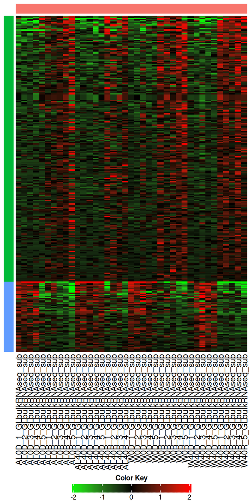

```r
if (!is.null(params$heat_data) && !is.null(params$heat_bar)) {
  heat_colors <- unlist(strsplit(params$heatmap_color_select, "-"))

  deg_heatmap(
    df = params$heat_data,
    bar = params$heat_bar,
    heatmap_color_select = heat_colors,
    cluster_rows = FALSE
  )
}
```

## Volcano Plot

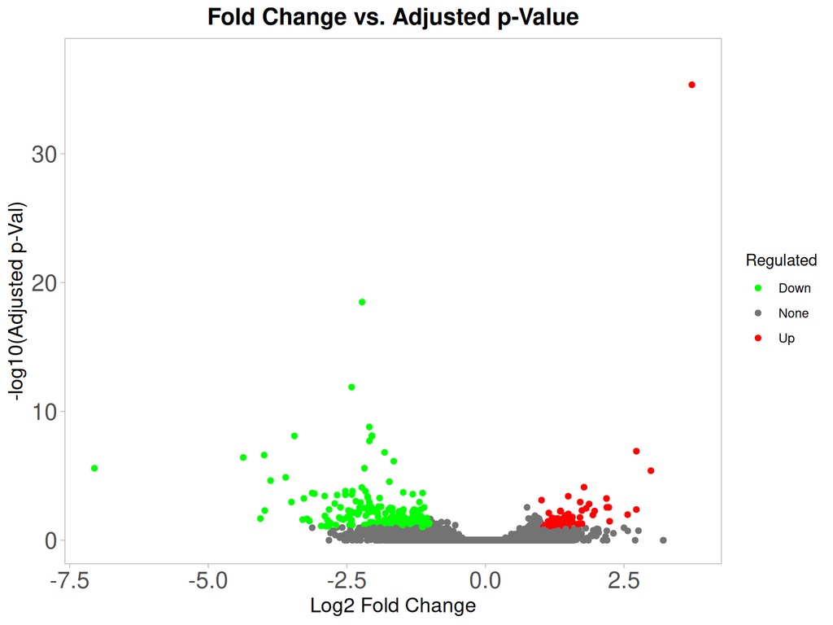

```r
if (!is.null(params$vol_data) && !is.null(params$vol_data$data)) {
  p <- plot_volcano(
    data = params$vol_data$data,
    plot_colors = params$plot_colors,
    anotate_genes = params$gene_labels_volcano
  )
  p <- refine_ggplot2(
    p = p,
    gridline = params$plot_grid_lines,
    ggplot2_theme = params$ggplot2_theme
  )
  print(p)
}
```

## MA Plot

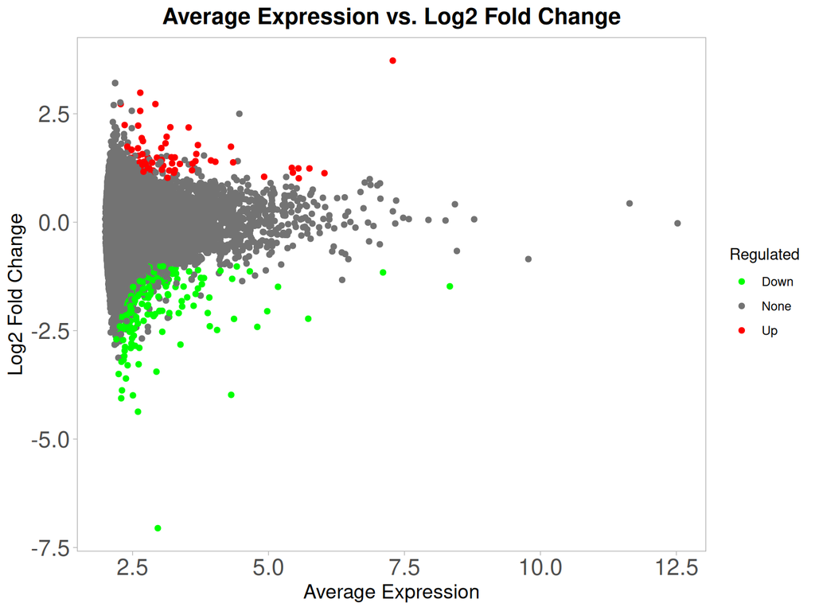

```r
if (!is.null(params$vol_data) && !is.null(params$vol_data$data)) {
  p <- plot_ma(
    data = params$vol_data$data,
    plot_colors = params$plot_colors,
    anotate_genes = params$gene_labels_ma
  )
  p <- refine_ggplot2(
    p = p,
    gridline = params$plot_grid_lines,
    ggplot2_theme = params$ggplot2_theme
  )
  print(p)
}
```

## Scatter Plot

[figure not shown]

```r
if (!is.null(params$top_genes) && !is.null(params$comparisons)) {
  p <- plot_deg_scatter(
    select_contrast = params$select_contrast,
    comparisons = params$comparisons,
    top_genes = params$top_genes,
    limma_p_val = params$limma_p_val,
    limma_fc = params$limma_fc,
    contrast_samples = params$contrast_samples,
    processed_data = params$processed_data,
    sample_info = params$sample_info,
    plot_colors = params$plot_colors,
    all_gene_names = params$all_gene_names,
    select_gene_id = params$select_gene_id,
    anotate_genes = params$gene_labels_scatter
  )
  p <- refine_ggplot2(
    p = p,
    gridline = params$plot_grid_lines,
    ggplot2_theme = params$ggplot2_theme
  )
  print(p)
}
```

Generated using iDEP v2.4.3 (https://bioinformatics.sdstate.edu/idep). 2025-12-09 20:57:07 UTC. Accuracy not guaranteed.